# Practical Machine Learning Course Project

# Synopsis

The purpose of this document is to identify whether it is possible to predict whether a person can measure his/her physical activity quantitatively, i.e., does he/she perform the exercise correctly or not. We will be using the dataset provided by Quantified Self Movement, which consists of the measurements by accelerometers placed on the belt, forearm, arm and dumbbell of 6 subjects. According to the out-of-sample error of the machine learning algorithm, it is indeed possible to predict, whether they performed the exercise correctly or not.

More information can be found here: http://groupware.les.inf.puc-rio.br/har

# Preliminary steps

Loading necessary libraries

```r
suppressWarnings(suppressMessages(library(randomForest)))
suppressWarnings(suppressMessages(library(caret)))
suppressWarnings(suppressMessages(library(corrplot)))
```

## Loading data

```r
train_data_url <- "http://d396qusza40orc.cloudfront.net/predmachlearn/pml-training.csv"
test_data_url <- "http://d396qusza40orc.cloudfront.net/predmachlearn/pml-testing.csv"

download.file(url = train_data_url, destfile = "pml-training.csv")
download.file(url = test_data_url, destfile = "pml-testing.csv")

train_csv <- read.table("pml-training.csv", sep = ",", header = TRUE, quote = "\"")
dim(train_csv)
```

```
## [1] 19622   160
```

```r
test_csv <- read.table("pml-testing.csv", sep = ",", header = TRUE, quote = "\"")
dim(test_csv)
```

```
## [1]  20 160
```

Let’s see what’s inside.

```r
str(train_csv, list.len = 200)
```

```
## 'data.frame':    19622 obs. of  160 variables:
##  $ X                       : int  1 2 3 4 5 6 7 8 9 10 ...
##  $ user_name               : Factor w/ 6 levels "adelmo","carlitos",..: 2 2 2 2 2 2 2 2 2 2 ...
##  $ raw_timestamp_part_1    : int  1323084231 1323084231 1323084231 1323084232 1323084232 1323084232 1323084232 1323084232 1323084232 1323084232 ...
##  $ raw_timestamp_part_2    : int  788290 808298 820366 120339 196328 304277 368296 440390 484323 484434 ...
##  $ cvtd_timestamp          : Factor w/ 20 levels "02/12/2011 13:32",..: 9 9 9 9 9 9 9 9 9 9 ...
##  $ new_window              : Factor w/ 2 levels "no","yes": 1 1 1 1 1 1 1 1 1 1 ...
##  $ num_window              : int  11 11 11 12 12 12 12 12 12 12 ...
##  $ roll_belt               : num  1.41 1.41 1.42 1.48 1.48 1.45 1.42 1.42 1.43 1.45 ...
##  $ pitch_belt              : num  8.07 8.07 8.07 8.05 8.07 8.06 8.09 8.13 8.16 8.17 ...
##  $ yaw_belt                : num  -94.4 -94.4 -94.4 -94.4 -94.4 -94.4 -94.4 -94.4 -94.4 -94.4 ...
##  $ total_accel_belt        : int  3 3 3 3 3 3 3 3 3 3 ...
##  $ kurtosis_roll_belt      : Factor w/ 397 levels "","-0.016850",..: 1 1 1 1 1 1 1 1 1 1 ...
##  $ kurtosis_picth_belt     : Factor w/ 317 levels "","-0.021887",..: 1 1 1 1 1 1 1 1 1 1 ...
##  $ kurtosis_yaw_belt       : Factor w/ 2 levels "","#DIV/0!": 1 1 1 1 1 1 1 1 1 1 ...
```

[output cut: 146 more lines]

```r
str(test_csv, list.len = 200)
```

```
## 'data.frame':    20 obs. of  160 variables:
##  $ X                       : int  1 2 3 4 5 6 7 8 9 10 ...
##  $ user_name               : Factor w/ 6 levels "adelmo","carlitos",..: 6 5 5 1 4 5 5 5 2 3 ...
##  $ raw_timestamp_part_1    : int  1323095002 1322673067 1322673075 1322832789 1322489635 1322673149 1322673128 1322673076 1323084240 1322837822 ...
##  $ raw_timestamp_part_2    : int  868349 778725 342967 560311 814776 510661 766645 54671 916313 384285 ...
##  $ cvtd_timestamp          : Factor w/ 11 levels "02/12/2011 13:33",..: 5 10 10 1 6 11 11 10 3 2 ...
##  $ new_window              : Factor w/ 1 level "no": 1 1 1 1 1 1 1 1 1 1 ...
##  $ num_window              : int  74 431 439 194 235 504 485 440 323 664 ...
##  $ roll_belt               : num  123 1.02 0.87 125 1.35 -5.92 1.2 0.43 0.93 114 ...
##  $ pitch_belt              : num  27 4.87 1.82 -41.6 3.33 1.59 4.44 4.15 6.72 22.4 ...
##  $ yaw_belt                : num  -4.75 -88.9 -88.5 162 -88.6 -87.7 -87.3 -88.5 -93.7 -13.1 ...
##  $ total_accel_belt        : int  20 4 5 17 3 4 4 4 4 18 ...
##  $ kurtosis_roll_belt      : logi  NA NA NA NA NA NA ...
##  $ kurtosis_picth_belt     : logi  NA NA NA NA NA NA ...
##  $ kurtosis_yaw_belt       : logi  NA NA NA NA NA NA ...
```

[output cut: 146 more lines]

## Cleaning data

Let’s remove features for which some information is missing (NA values). Same columns should remain in both the training and test sets.

```r
train_full <- colSums(is.na(train_csv)) == 0
test_full <- colSums(is.na(test_csv)) == 0

train_full <- names(train_full[train_full])
test_full <- names(test_full[test_full])

train_csv <- train_csv[,names(train_csv) %in% c(intersect(train_full, test_full), "classe")]
test_csv <- test_csv[,names(test_csv) %in% intersect(train_full, test_full)]
```

Number of complete cases is equal to the number of rows, which is very good.

```r
dim(train_csv)
```

```
## [1] 19622    60
```

```r
dim(test_csv)
```

```
## [1] 20 59
```

```r
sum(complete.cases(train_csv))
```

```
## [1] 19622
```

```r
sum(complete.cases(test_csv))
```

```
## [1] 20
```

Let’s view whether there are clear correlations between the outcome and some predictors.

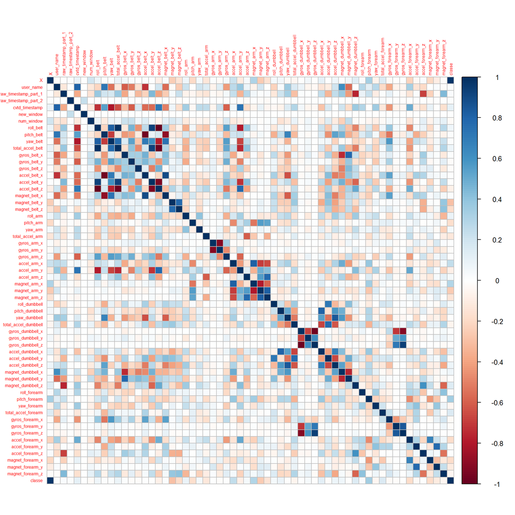

```r
df <- train_csv

for (i in 1:ncol(df)) {
  col <- df[,i]

  if (class(col) == "character") {
    col <- as.numeric(as.factor(col))
  } else if (class(col) == "factor" | class(col) == "logical" | class(col) == "Date") {
    col <- as.numeric(col)
  }

  df[,i] <- col
}

dm <- as.matrix(df)
cr <- cor(dm)
corrplot(cr, method = "color", addgrid.col = "grey", tl.cex = 0.5)
```

Variable X has very high correlation with the outcome, so it needs to be removed, or else it will make the model grossly overfit the data.

```r
train_csv$X <- NULL
test_csv$X <- NULL
```

# Modeling

Setting the seed enables us to exactly reproduce the results later.

```r
set.seed(1)
```

```r
train_idx <- createDataPartition(train_csv$classe, p = 0.7, list = FALSE)

train_data <- train_csv[train_idx,]
test_data <- train_csv[-train_idx,]
```

Training the model with 5-fold cross-validation.

```r
control <- trainControl(method = "cv", 5)
mod <- train(classe ~ ., data = train_data, trControl = control, method = "rf", ntree = 30)
mod
```

```
## Random Forest
##
## 13737 samples
##    58 predictor
##     5 classes: 'A', 'B', 'C', 'D', 'E'
##
## No pre-processing
## Resampling: Cross-Validated (5 fold)
##
## Summary of sample sizes: 10990, 10990, 10989, 10990, 10989
##
## Resampling results across tuning parameters:
##
##   mtry  Accuracy   Kappa      Accuracy SD   Kappa SD
##    2    0.9831841  0.9787214  0.0024470418  0.0030973856
##   41    0.9989808  0.9987109  0.0007002531  0.0008856457
##   80    0.9978889  0.9973297  0.0011335208  0.0014338411
##
## Accuracy was used to select the optimal model using  the largest value.
## The final value used for the model was mtry = 41.
```

Based on cross-validation, we estimate the out-of-sample error to be very small: only **0.1%**.

Trying out our model on the test data and evaluating the out-of-sample results.

```r
pred <- predict(mod, test_data)
confusionMatrix(test_data$classe, pred)
```

```
## Confusion Matrix and Statistics
##
##           Reference
## Prediction    A    B    C    D    E
##          A 1674    0    0    0    0
##          B    1 1136    2    0    0
##          C    0    0 1026    0    0
##          D    0    0    0  964    0
##          E    0    0    0    1 1081
##
## Overall Statistics
##
##                Accuracy : 0.9993
##                  95% CI : (0.9983, 0.9998)
##     No Information Rate : 0.2846
##     P-Value [Acc > NIR] : < 2.2e-16
##
##                   Kappa : 0.9991
##  Mcnemar's Test P-Value : NA
##
## Statistics by Class:
##
##                      Class: A Class: B Class: C Class: D Class: E
## Sensitivity            0.9994   1.0000   0.9981   0.9990   1.0000
## Specificity            1.0000   0.9994   1.0000   1.0000   0.9998
## Pos Pred Value         1.0000   0.9974   1.0000   1.0000   0.9991
## Neg Pred Value         0.9998   1.0000   0.9996   0.9998   1.0000
## Prevalence             0.2846   0.1930   0.1747   0.1640   0.1837
## Detection Rate         0.2845   0.1930   0.1743   0.1638   0.1837
## Detection Prevalence   0.2845   0.1935   0.1743   0.1638   0.1839
## Balanced Accuracy      0.9997   0.9997   0.9990   0.9995   0.9999
```

```r
accuracy <- round(as.numeric(postResample(pred, test_data$classe)[1]) * 100, 2)
out_of_sample_error <- 100 - accuracy
```

Accuracy: **99.93%**  
Out-of-sample error: **0.07%**

# Final prediction

Let’s perform the final prediction on the dataset we kept until the end, to get the results that will be submitted to Coursera for automatic grading.

```r
predict(mod, test_csv)
```

```
##  [1] B A B A A E D B A A B C B A E E A B B B
## Levels: A B C D E
```